# Portfolio Report 7: Debugging and Performance

Jake Spiteri

2019

# Debugging

When writing code it is common to encounter problems which you do not expect. Functions for complex statistical tasks often do not return the output you want — in some cases it is obvious, but not always. It’s important to have a strong understanding of the debugging options offered by R and particular IDEs such as RStudio. Knowledge of these tools can make debugging much more efficient.

When debugging code we should:

- Try to understand exactly what the error is. We can gain a greater understanding if we think about our inputs and what the expected output should be. Often this is not so simple as the error occurs within a function and the error message doesn’t provide much information.
- Try to produce a reproducible and minimal example of the error. If this example demonstrates a bug in someone else’s code, the bug should be reported with the minimal example. The `reprex` package can help in producing reproducible examples to post online.

The best way to avoid debugging code is to change the way you write code. When writing a complicated function it is often best to write small pieces at a time, and check if the function still works as expected. If you write a long and complicated function without testing, it will be hard to debug the code. If you start with small pieces it becomes easy to see when the code ‘breaks’.

## Example of debugging

Consider an example in which we have a dataset of pairs of observations $\{x_i, y_i\}_{i=1}^n$. We will generate this data using $x_i \sim U[-10,10],$ for $i=1,\dots,n$, and $y_i = x_i + \epsilon_i$, where $\epsilon \sim N(0,4)$. We will fit a linear model with the covariate $x$. We will clumsily implement the least squares solution.

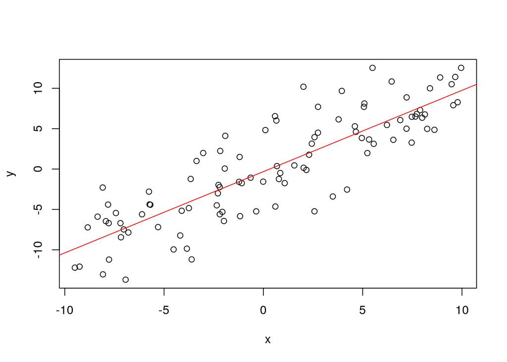

```r
x <- runif(100,-10,10)
y <- (x) + rnorm(100,0,4)

# built-in function
model <- lm(y~x)
plot(x,y)
abline(model$coefficients, col="red")
```

```r
linear_regression <- function(X,y) {
  beta <- solve(X %*% t(X)) %*% t(X) %*% y
  return(beta %*% X)
}
x <- cbind(rep(1,100), x)
linear_regression(x, y)
```

```
## Error in solve.default(X %*% t(X)): system is computationally singular: reciprocal condition number = 1.82462e-21
```

We cannot perform the matrix inverse as our system is computationally singular. There are a number of reasons that this may have happened, but I suspect that there may simply be a transpose where there shouldn’t be. However, there may also be a larger problem. In some cases our variables within the function are not what we expect them to be. In this case we are trying to compute $(XX^T)^{-1}$, when we should be computing $(X^TX)^{-1}$.

```r
traceback()
```

```
## No traceback available
```

The RStudio IDE provides great resources for debugging. An intuitive method one may implement is to place multiple `print(<variable>)`s in the function to determine the value of different variables. A *much* more effective method is to place `broswer()` within your code. This opens an interactive debugging environment.

My preferred method of debugging code is to enter `debug(<function>)` into the console. Then when the specified function is ran we will immediately enter the interactive debugging environment within RStudio. When coding non-trivial functions this is *life changing*. This is always my first suggestion when someone can’t find a bug in their code. You can go through the function’s computation line-by-line, and print variables’ values via the console.

It clearly isn’t possible to demonstrate the interactive environment within this document. However if we were in the interactive environment, we would see that `solve(t(x) %*% x)` is possible.

```r
linear_regression <- function(X,y) {
  beta <- solve(t(X) %*% X) %*% t(X) %*% y
  return(beta %*% X)
}
linear_regression(x, y)
```

```
## Error in beta %*% X: non-conformable arguments
```

We have solved one problem, but we have another. We now have non-conformable arguments. If we enter the interactive debugging environment we can see that beta has dimension (2,1) and X has dimension (100,2). Clearly this matrix multiplication isn’t possible — we should be computing `X %*% beta`. This produces a column vector of predictions.

```r
linear_regression <- function(X,y) {
  beta <- solve(t(X) %*% X) %*% t(X) %*% y
  return(X %*% beta)
}
linear_regression(x, y)[1:5]
```

```
## [1] -9.626399  3.931511 -3.944131 -7.783625 -3.992915
```

We have successfully output predictions!

# Profiling

Profiling is an analysis technique which tests the memory and time complexity of a program. When writing code we may find that some functions take unexpectedly long to run. R makes profiling quite easy via the package `profvis`.

```r
library(profvis)
```

[output not shown]

This package is a *statistical* profiler. It uses operating system interrupts to determine which code is currently operating. With this information we can clearly see which operations are taking a long time to run, while the profiler adds little overhead to the computation. This is particularly useful when writing multiple lines of code and when practicing functional programming. When nesting functions within functions it may become difficult to tell which function is responsible for long computation times. If the profiler tells us that one function accounts for a majority of the computation time, we have a clear understanding of what code to optimize. Otherwise we may spend a long time optimizing the performance of functions that account for very little of the computation.

Note that a statistical profiler is very different to an instrumental profiler, which counts the number of times that an operation is performed. In such a case one must manually add counters to their code, and this adds substantial overhead to the computation.

## Example

Here we will use kernel regression as an example. We quickly recall the kernel method setup:

Our estimator takes the form
$$f(x; w_{LS-R}) = k(K + \lambda I)^{-1}y^T$$
where $k^{(i)} = k(x, x_i) = \langle \phi(x), \phi(x_i)\rangle$, $K_{i,j} = k(x_i, x_j)$.

We will implement a kernel method using the radial basis function. In this first implementation we are going to compute the $n \times n$ matrix $K$ by using two for loops. This function will produce one prediction at a time, and so we must loop over it a number of times in order to make more than one prediction. **Note**: We must recompute our estimator for every prediction.

```r
rbf_function <- function(vec1, vec2, bandwidth) {
  return(exp(-norm(vec1 - vec2, type = "2")^2/bandwidth^2))
}

kernel_regression_1 <- function(X, y, x.pred, lambda, bandwidth) {
  n <- ncol(y)
  n.pred <- ncol(x.pred)
  k <- c()
  for (i in 1:n) {
      k <- c(k, rbf_function(x.pred, X[,i], bandwidth))
  }

  K <- matrix(nrow=n, ncol=n)
  for (i in 1:n) {
    for (j in 1:n) {
      K[i,j] <- rbf_function(X[,i], X[,j], bandwidth)
    }
  }
  return(k %*% solve(K + lambda * diag(1,n)) %*% t(y))
}
```

We simulate some basic data in order to evaluate the function.

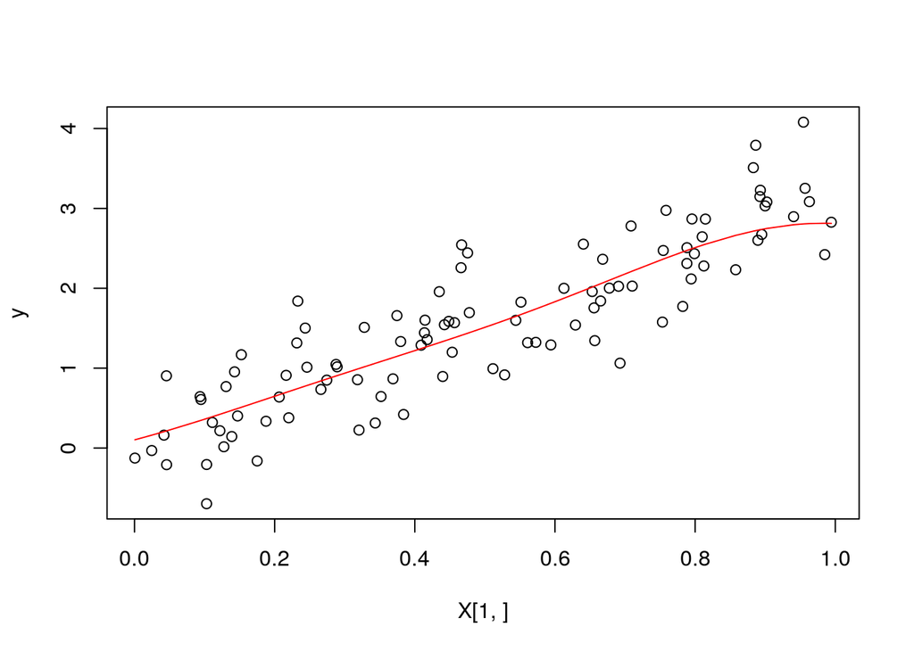

```r
set.seed(123)
X <- matrix(runif(100), ncol=100)
X <- rbind(X, rep(1,100))
y <- matrix(3.2*X[1,] + rnorm(100,0,0.5), ncol=100)

# a wrapper function which allows us to produce multiple predictions
multiple_pred <- function(X, y, x.pred, lambda, bandwidth) {
  pred <- c()
  for (i in 1:ncol(x.pred)) {
    pred <- c(pred, kernel_regression_1(X, y, x.pred[,i], lambda, bandwidth))
  }
  return(pred)
}

# sanity check --- we plot our predicted values
predictions <- multiple_pred(X, y, X, 1, 0.5)
plot(X[1,], y)
lines(sort(X[1,]), predictions[order(X[1,])], col = "red")
```

```r
# we use profvis to analyse the code
profvis(multiple_pred(X, y, X, 1, 0.5))
```

[output not shown]

```r
kernel_regression_2 <- function(X, y, x.pred, lambda, bandwidth) {
  n <- ncol(y)
  n.pred <- ncol(x.pred)
  k <- matrix(nrow=n.pred, ncol = n)
  for (i in 1:n.pred) {
    for (j in 1:n) {
      k[i,j] <- rbf_function(x.pred[,i], X[,j], bandwidth)
    }
  }

  K <- matrix(nrow=n, ncol=n)
  for (i in 1:n) {
    for (j in 1:n) {
      K[i,j] <- rbf_function(X[,i], X[,j], bandwidth)
    }
  }
  return(k %*% solve(K + lambda * diag(1,n)) %*% t(y))
}
```

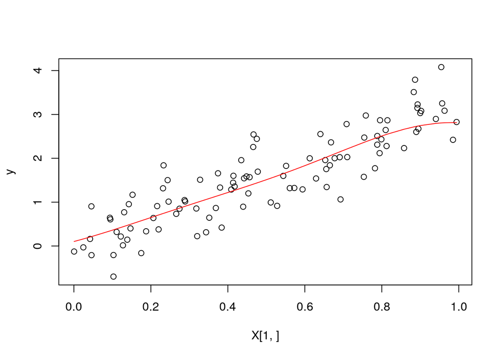

```r
# sanity check --- we plot our predicted values
predictions <- kernel_regression_2(X, y, X, 1, 0.5)
plot(X[1,], y)
lines(sort(X[1,]), predictions[order(X[1,])], col = "red")
```

```r
# profvis
profvis(kernel_regression_2(X, y, X, 1, 0.5))
```

[output not shown]

```r
kernel_regression_3 <- function(X, y, x.pred, lambda, bandwidth) {
  n <- ncol(y)
  n.pred <- ncol(x.pred)
  k <- matrix(nrow=n.pred, ncol = n)

  K <- outer(
    1:n, 1:n,
    Vectorize(function(i,j) rbf_function(X[,i], X[,j], bandwidth))
  )

  return(k %*% solve(K + lambda * diag(1,n)) %*% t(y))
}
```

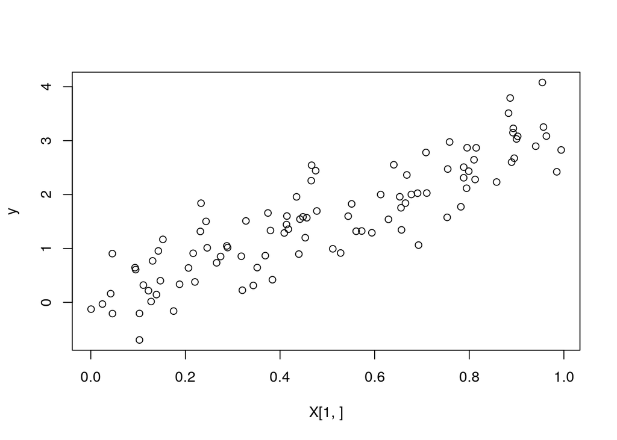

```r
# sanity check --- we plot our predicted values
predictions <- kernel_regression_3(X, y, X, 1, 0.5)
plot(X[1,], y)
lines(sort(X[1,]), predictions[order(X[1,])], col = "red")
```

```r
# profvis
profvis(kernel_regression_3(X, y, X, 1, 0.5))
```

[output not shown]

## Memory management in R

R uses pass-by-value semantics in its function calls. This means that if we assign some variable $x$ to be equal to another variable $y$, then changing the value of $y$ will not change the value of $x$. Code in R is interpreted line-by-line. This means that coding in R is rather intuitive and easy to reason about, but it also means that the code produced may not perform well — particularly in comparison to languages such as C which implement pass-by-reference semantics. After algorithmic complexity, memory management is one of the most important factors in performance.

There are many things that R does in the background to improve performance. When editing elements in a matrix it seems illogical to work with multiple copies of the matrix, and so R indexes into the element and modifies it in place. In some cases R will copy the matrix and modify it.

```r
library(pryr)
```

[output not shown]

```r
# modify in place
x <- rep(1,2)
x[2] <- 2

# assign y to be x
y <- x

# show y is not a copy of x --- R just points to x
# refs(x) tells us how many variables point to this location
c(address(x), refs(x))
```

[output not shown]

```r
x <- rep(1,10)
c(address(x), refs(x))
```

[output not shown]

```r
z <- x
c(address(x), refs(x))
```

[output not shown]

```r
x[5] <- 2
c(address(x), refs(x)) # creates a copy of x and modifies it
```

[output not shown]

When writing code it is best to avoid creating copies of an array as this is an inefficient use of memory. If you are worried about memory efficiency you should routinely use `address()` and `refs()` in order to test when objects are being copied. It may be useful to know that primitive functions in R do not increment the `refs()` count, whereas all non-primitive functions increment the `refs()` count. If memory efficiency is very important to you, it may be better to use `Rcpp` and write your function in C++.

```r
# modifies in place because <- <vector> is a primitive function
x <- 1:5
for(i in 1:5) {
  x[i] <- x[i] - 1
  print(c(address(x), refs(x)))
}
```

[output not shown]

```r
# creates a copy because <- <data.frame> is not a primitive function
# we must be careful when working with non-primitive data structures
# problem occurs because refs counter is incremented and thus R
# copies the object
x <- data.frame(1:5)
for(i in 1:5) {
  x[i,1] <- x[i,1] - 1
  print(c(address(x), refs(x)))
}
```

[output not shown]